# Telco Customer Churn Analysis

### Import Libraries

```python
# import basic data modules
import pandas as pd
import numpy as np
import seaborn as sns
import matplotlib.pyplot as plt

# import classifier models
from sklearn import linear_model
from sklearn.linear_model import LogisticRegression
from sklearn.ensemble import RandomForestClassifier
from sklearn.linear_model import Perceptron
from sklearn.tree import DecisionTreeClassifier
from sklearn.neighbors import KNeighborsClassifier
from sklearn.svm import LinearSVC
from sklearn.naive_bayes import GaussianNB
from sklearn.linear_model import SGDClassifier
from xgboost import XGBClassifier
from sklearn.calibration import CalibratedClassifierCV

# import helper modules
from sklearn.preprocessing import MinMaxScaler
from sklearn.model_selection import train_test_split
from sklearn.model_selection import cross_validate
from sklearn.metrics import plot_confusion_matrix, f1_score
from sklearn.metrics import roc_curve
from sklearn.metrics import roc_auc_score
from sklearn.metrics import plot_confusion_matrix, f1_score
from sklearn.metrics import roc_curve
from sklearn.metrics import roc_auc_score


# ignore warnings
import warnings
warnings.filterwarnings('ignore')
warnings.warn('ignore')
```

```python
# load data
raw_data = pd.read_excel('Telco_customer_churn.xlsx')

# check the first 5 rows
raw_data.head()
```

|  | CustomerID | Count | Country | State | City | Zip Code | Lat Long | Latitude | Longitude | Gender | Senior Citizen | Partner | Dependents | Tenure Months | Phone Service | Multiple Lines | Internet Service | Online Security | Online Backup | Device Protection | Tech Support | Streaming TV | Streaming Movies | Contract | Paperless Billing | Payment Method | Monthly Charges | Total Charges | Churn Label | … |
| --- | --- | --- | --- | --- | --- | --- | --- | --- | --- | --- | --- | --- | --- | --- | --- | --- | --- | --- | --- | --- | --- | --- | --- | --- | --- | --- | --- | --- | --- | --- |
| 0 | 3668-QPYBK | 1 | United States | California | Los Angeles | 90003 | 33.964131, -118.272783 | 33.964131 | -118.272783 | Male | No | No | No | 2 | Yes | No | DSL | Yes | Yes | No | No | No | No | Month-to-month | Yes | Mailed check | 53.85 | 108.15 | Yes | … |
| 1 | 9237-HQITU | 1 | United States | California | Los Angeles | 90005 | 34.059281, -118.30742 | 34.059281 | -118.307420 | Female | No | No | Yes | 2 | Yes | No | Fiber optic | No | No | No | No | No | No | Month-to-month | Yes | Electronic check | 70.70 | 151.65 | Yes | … |
| 2 | 9305-CDSKC | 1 | United States | California | Los Angeles | 90006 | 34.048013, -118.293953 | 34.048013 | -118.293953 | Female | No | No | Yes | 8 | Yes | Yes | Fiber optic | No | No | Yes | No | Yes | Yes | Month-to-month | Yes | Electronic check | 99.65 | 820.5 | Yes | … |
| 3 | 7892-POOKP | 1 | United States | California | Los Angeles | 90010 | 34.062125, -118.315709 | 34.062125 | -118.315709 | Female | No | Yes | Yes | 28 | Yes | Yes | Fiber optic | No | No | Yes | Yes | Yes | Yes | Month-to-month | Yes | Electronic check | 104.80 | 3046.05 | Yes | … |
| 4 | 0280-XJGEX | 1 | United States | California | Los Angeles | 90015 | 34.039224, -118.266293 | 34.039224 | -118.266293 | Male | No | No | Yes | 49 | Yes | Yes | Fiber optic | No | Yes | Yes | No | Yes | Yes | Month-to-month | Yes | Bank transfer (automatic) | 103.70 | 5036.3 | Yes | … |

```python
print('Shape:',raw_data.shape)
```

```
Shape: (7043, 33)
```

# Greeting Data

```python
# quick look of the first and last 5 rows
pd.set_option('max_columns', None)
display(raw_data.head())
display(raw_data.tail())
```

|  | CustomerID | Count | Country | State | City | Zip Code | Lat Long | Latitude | Longitude | Gender | Senior Citizen | Partner | Dependents | Tenure Months | Phone Service | Multiple Lines | Internet Service | Online Security | Online Backup | Device Protection | Tech Support | Streaming TV | Streaming Movies | Contract | Paperless Billing | Payment Method | Monthly Charges | Total Charges | Churn Label | … |
| --- | --- | --- | --- | --- | --- | --- | --- | --- | --- | --- | --- | --- | --- | --- | --- | --- | --- | --- | --- | --- | --- | --- | --- | --- | --- | --- | --- | --- | --- | --- |
| 0 | 3668-QPYBK | 1 | United States | California | Los Angeles | 90003 | 33.964131, -118.272783 | 33.964131 | -118.272783 | Male | No | No | No | 2 | Yes | No | DSL | Yes | Yes | No | No | No | No | Month-to-month | Yes | Mailed check | 53.85 | 108.15 | Yes | … |
| 1 | 9237-HQITU | 1 | United States | California | Los Angeles | 90005 | 34.059281, -118.30742 | 34.059281 | -118.307420 | Female | No | No | Yes | 2 | Yes | No | Fiber optic | No | No | No | No | No | No | Month-to-month | Yes | Electronic check | 70.70 | 151.65 | Yes | … |
| 2 | 9305-CDSKC | 1 | United States | California | Los Angeles | 90006 | 34.048013, -118.293953 | 34.048013 | -118.293953 | Female | No | No | Yes | 8 | Yes | Yes | Fiber optic | No | No | Yes | No | Yes | Yes | Month-to-month | Yes | Electronic check | 99.65 | 820.5 | Yes | … |
| 3 | 7892-POOKP | 1 | United States | California | Los Angeles | 90010 | 34.062125, -118.315709 | 34.062125 | -118.315709 | Female | No | Yes | Yes | 28 | Yes | Yes | Fiber optic | No | No | Yes | Yes | Yes | Yes | Month-to-month | Yes | Electronic check | 104.80 | 3046.05 | Yes | … |
| 4 | 0280-XJGEX | 1 | United States | California | Los Angeles | 90015 | 34.039224, -118.266293 | 34.039224 | -118.266293 | Male | No | No | Yes | 49 | Yes | Yes | Fiber optic | No | Yes | Yes | No | Yes | Yes | Month-to-month | Yes | Bank transfer (automatic) | 103.70 | 5036.3 | Yes | … |

|  | CustomerID | Count | Country | State | City | Zip Code | Lat Long | Latitude | Longitude | Gender | Senior Citizen | Partner | Dependents | Tenure Months | Phone Service | Multiple Lines | Internet Service | Online Security | Online Backup | Device Protection | Tech Support | Streaming TV | Streaming Movies | Contract | Paperless Billing | Payment Method | Monthly Charges | Total Charges | Churn Label | … |
| --- | --- | --- | --- | --- | --- | --- | --- | --- | --- | --- | --- | --- | --- | --- | --- | --- | --- | --- | --- | --- | --- | --- | --- | --- | --- | --- | --- | --- | --- | --- |
| 7038 | 2569-WGERO | 1 | United States | California | Landers | 92285 | 34.341737, -116.539416 | 34.341737 | -116.539416 | Female | No | No | No | 72 | Yes | No | No | No internet service | No internet service | No internet service | No internet service | No internet service | No internet service | Two year | Yes | Bank transfer (automatic) | 21.15 | 1419.4 | No | … |
| 7039 | 6840-RESVB | 1 | United States | California | Adelanto | 92301 | 34.667815, -117.536183 | 34.667815 | -117.536183 | Male | No | Yes | Yes | 24 | Yes | Yes | DSL | Yes | No | Yes | Yes | Yes | Yes | One year | Yes | Mailed check | 84.80 | 1990.5 | No | … |
| 7040 | 2234-XADUH | 1 | United States | California | Amboy | 92304 | 34.559882, -115.637164 | 34.559882 | -115.637164 | Female | No | Yes | Yes | 72 | Yes | Yes | Fiber optic | No | Yes | Yes | No | Yes | Yes | One year | Yes | Credit card (automatic) | 103.20 | 7362.9 | No | … |
| 7041 | 4801-JZAZL | 1 | United States | California | Angelus Oaks | 92305 | 34.1678, -116.86433 | 34.167800 | -116.864330 | Female | No | Yes | Yes | 11 | No | No phone service | DSL | Yes | No | No | No | No | No | Month-to-month | Yes | Electronic check | 29.60 | 346.45 | No | … |
| 7042 | 3186-AJIEK | 1 | United States | California | Apple Valley | 92308 | 34.424926, -117.184503 | 34.424926 | -117.184503 | Male | No | No | No | 66 | Yes | No | Fiber optic | Yes | No | Yes | Yes | Yes | Yes | Two year | Yes | Bank transfer (automatic) | 105.65 | 6844.5 | No | … |

- 'CustomeID' is an irrelevant column for us to classify churn. We may drop it.
- 'Lat Long', 'Latitude', 'Longitude' and 'Zip Code' all indicate the geogorical information. We may only keep 'Zip Code'.
- 'Churn Label', 'Churn Value' and 'Churn Score' may be three taget columns. We may only keep one target column. 'Churn Score' needs further investigation to determine if it is a target column.

```python
# check for the numerical variables' statistics
raw_data.describe()
```

|  | Count | Zip Code | Latitude | Longitude | Tenure Months | Monthly Charges | Churn Value | Churn Score | CLTV |
| --- | --- | --- | --- | --- | --- | --- | --- | --- | --- |
| count | 7043.0 | 7043.000000 | 7043.000000 | 7043.000000 | 7043.000000 | 7043.000000 | 7043.000000 | 7043.000000 | 7043.000000 |
| mean | 1.0 | 93521.964646 | 36.282441 | -119.798880 | 32.371149 | 64.761692 | 0.265370 | 58.699418 | 4400.295755 |
| std | 0.0 | 1865.794555 | 2.455723 | 2.157889 | 24.559481 | 30.090047 | 0.441561 | 21.525131 | 1183.057152 |
| min | 1.0 | 90001.000000 | 32.555828 | -124.301372 | 0.000000 | 18.250000 | 0.000000 | 5.000000 | 2003.000000 |
| 25% | 1.0 | 92102.000000 | 34.030915 | -121.815412 | 9.000000 | 35.500000 | 0.000000 | 40.000000 | 3469.000000 |
| 50% | 1.0 | 93552.000000 | 36.391777 | -119.730885 | 29.000000 | 70.350000 | 0.000000 | 61.000000 | 4527.000000 |
| 75% | 1.0 | 95351.000000 | 38.224869 | -118.043237 | 55.000000 | 89.850000 | 1.000000 | 75.000000 | 5380.500000 |
| max | 1.0 | 96161.000000 | 41.962127 | -114.192901 | 72.000000 | 118.750000 | 1.000000 | 100.000000 | 6500.000000 |

- 'Count' only contains a single value, 1. It has no value for our analysis.

```python
# check for the object variables' statistics
raw_data.describe(include=['object'])
```

|  | CustomerID | Country | State | City | Lat Long | Gender | Senior Citizen | Partner | Dependents | Phone Service | Multiple Lines | Internet Service | Online Security | Online Backup | Device Protection | Tech Support | Streaming TV | Streaming Movies | Contract | Paperless Billing | Payment Method | Total Charges | Churn Label | Churn Reason |
| --- | --- | --- | --- | --- | --- | --- | --- | --- | --- | --- | --- | --- | --- | --- | --- | --- | --- | --- | --- | --- | --- | --- | --- | --- |
| count | 7043 | 7043 | 7043 | 7043 | 7043 | 7043 | 7043 | 7043 | 7043 | 7043 | 7043 | 7043 | 7043 | 7043 | 7043 | 7043 | 7043 | 7043 | 7043 | 7043 | 7043 | 7043.0 | 7043 | 1869 |
| unique | 7043 | 1 | 1 | 1129 | 1652 | 2 | 2 | 2 | 2 | 2 | 3 | 3 | 3 | 3 | 3 | 3 | 3 | 3 | 3 | 2 | 4 | 6531.0 | 2 | 20 |
| top | 3668-QPYBK | United States | California | Los Angeles | 33.964131, -118.272783 | Male | No | No | No | Yes | No | Fiber optic | No | No | No | No | No | No | Month-to-month | Yes | Electronic check | 20.2 | No | Attitude of support person |
| freq | 1 | 7043 | 7043 | 305 | 5 | 3555 | 5901 | 3641 | 5416 | 6361 | 3390 | 3096 | 3498 | 3088 | 3095 | 3473 | 2810 | 2785 | 3875 | 4171 | 2365 | 11.0 | 5174 | 192 |

- 'Country' and 'State' only contain the single values. They have no value for our analysis.

```python
# Check for data types and null values:
raw_data.info()
```

```
<class 'pandas.core.frame.DataFrame'>
RangeIndex: 7043 entries, 0 to 7042
Data columns (total 33 columns):
 #   Column             Non-Null Count  Dtype
---  ------             --------------  -----
 0   CustomerID         7043 non-null   object
 1   Count              7043 non-null   int64
 2   Country            7043 non-null   object
 3   State              7043 non-null   object
 4   City               7043 non-null   object
 5   Zip Code           7043 non-null   int64
 6   Lat Long           7043 non-null   object
 7   Latitude           7043 non-null   float64
 8   Longitude          7043 non-null   float64
 9   Gender             7043 non-null   object
```

[output cut: 25 more lines]

- 'Total Charges' has a wrong data type. It should be the type float.
- 'Churn Reason missed many values.

# Data Cleaning

- Missing values: 'Churn Reason missed many values.
- Further investigation: 'Churn Label', 'Churn Value' and 'Churn Score'
- Check for duplicated rows
- Correct data type: 'Total Charges'
- Drop: 'CustomeID', 'Lat Long', 'Latitude', 'Longitude', 'Count', 'Country', 'State' and other potential columns from the above

### Investigate Churn Reason

```python
# check for missing values
dataset = raw_data
missing_data = dataset.isnull()
print('Number of columns containing missing values:',missing_data.any().sum())
print("")
columns_with_null = []
for column in missing_data.any().index:
    if missing_data.any()[column] == True:
        columns_with_null.append(column)
        print(column)
        print(missing_data[column].value_counts())
        print("")
```

```
Number of columns containing missing values: 1

Churn Reason
True     5174
False    1869
Name: Churn Reason, dtype: int64
```

```python
# further investigate Churn Reason
raw_data['has_cr'] = raw_data['Churn Reason'].notnull().astype('int')
print(pd.crosstab(raw_data['has_cr'], raw_data['Churn Label'], margins=True))
raw_data.drop(['has_cr'], axis=1, inplace=True)
```

```
Churn Label    No   Yes   All
has_cr
0            5174     0  5174
1               0  1869  1869
All          5174  1869  7043
```

We confirmed that only rows recoreded as churned has the churn reason. This column cannot be included in modelling because it acts almost like a label itself. We can use it to derive why customer churn according which, the company can act proactively to keep the customers. This is can provide actionable insights after we identified churns using other columns. We will drop it after we have done the exploratory data analysis (EDA).

### Investigate potential target columns

```python
# potentially excessive target columns:
    # Churn Label, Churn Value, Churn Score
pd.crosstab(raw_data['Churn Label'], raw_data['Churn Value'], margins=True)
```

| Churn Value Churn Label | 0 | 1 | All |
| --- | --- | --- | --- |
| No | 5174 | 0 | 5174 |
| Yes | 0 | 1869 | 1869 |
| All | 5174 | 1869 | 7043 |

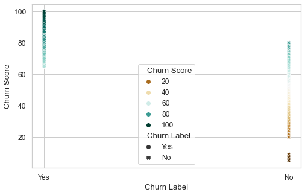

```
            Churn Score
                    max min       mean
Churn Label
No                   80   5  50.098183
Yes                 100  65  82.510433
```

```python
palette = sns.color_palette('BrBG', as_cmap=True)
sns.scatterplot(data=raw_data, x='Churn Label', y='Churn Score',
                hue='Churn Score', palette=palette, style='Churn Label')
plt.show()
print(raw_data.groupby('Churn Label').agg({'Churn Score' : ['max', 'min', 'mean']}))
```

- Churn Label and Churn Value are repliacted each other. We will use the Churn Label in EDA, and use Churn Value in modelling.
- Churn Score is highly correlated with Churn Label, but it is not directly indicating Churn because records with the same Churn Value may or may not churn, ie Churn Value=80. From the documentation, we learn that 'Churn Score' is a feature produced by a trained IBM model that captured some critical factors about churn behaviour. Since it is already a product of another ML model, we will train and evaluate our own model with and without the 'Churn Score' and compare the difference.

### Check for duplicated rows

```python
# check for duplicated rows
dataset = raw_data
duplicated_data = dataset.duplicated(keep=False)
print('Number of rows duplicated:', duplicated_data.sum())
print('')
duplicated_index = []
for row in duplicated_data.index:
    if duplicated_data[row] == True:
        duplicated_index.append(row)
        print(duplicated_data[row].value_counts())
        print('')
display(dataset.iloc[duplicated_index])
```

```
Number of rows duplicated: 0
```

|  | CustomerID | Count | Country | State | City | Zip Code | Lat Long | Latitude | Longitude | Gender | Senior Citizen | Partner | Dependents | Tenure Months | Phone Service | Multiple Lines | Internet Service | Online Security | Online Backup | Device Protection | Tech Support | Streaming TV | Streaming Movies | Contract | Paperless Billing | Payment Method | Monthly Charges | Total Charges | Churn Label | … |
| --- | --- | --- | --- | --- | --- | --- | --- | --- | --- | --- | --- | --- | --- | --- | --- | --- | --- | --- | --- | --- | --- | --- | --- | --- | --- | --- | --- | --- | --- | --- |

There is no duplicated record.

### Correct data type for Total Charge

```python
print('Before Correcting:', raw_data['Total Charges'].dtype)
raw_data['Total Charges'] = pd.to_numeric(raw_data['Total Charges'],errors='coerce')
print('After Correcting:', raw_data['Total Charges'].dtype)
```

```
Before Correcting: object
After Correcting: float64
```

```python
# check for null
null = raw_data['Total Charges'].isnull()
print('Number of null values found: ', null.sum())

na_index = raw_data[null].index
print('Row index:', na_index)
```

```
Number of null values found:  11
Row index: Int64Index([2234, 2438, 2568, 2667, 2856, 4331, 4687, 5104, 5719, 6772, 6840], dtype='int64')
```

### Drop uncessary columns

```python
# Clean the dataset
to_drop = ['CustomerID', 'Lat Long', 'Latitude', 'Longitude', 'Count', 'Country', 'State']
to_drop_after_EDA = ['Churn Reason', 'Churn Label']

EDA_data = raw_data.drop(to_drop, axis=1)
EDA_data.drop(na_index, axis=0, inplace=True)
print(EDA_data.shape)
EDA_data.head()
```

```
(7032, 26)
```

|  | City | Zip Code | Gender | Senior Citizen | Partner | Dependents | Tenure Months | Phone Service | Multiple Lines | Internet Service | Online Security | Online Backup | Device Protection | Tech Support | Streaming TV | Streaming Movies | Contract | Paperless Billing | Payment Method | Monthly Charges | Total Charges | Churn Label | Churn Value | Churn Score | CLTV | Churn Reason |
| --- | --- | --- | --- | --- | --- | --- | --- | --- | --- | --- | --- | --- | --- | --- | --- | --- | --- | --- | --- | --- | --- | --- | --- | --- | --- | --- |
| 0 | Los Angeles | 90003 | Male | No | No | No | 2 | Yes | No | DSL | Yes | Yes | No | No | No | No | Month-to-month | Yes | Mailed check | 53.85 | 108.15 | Yes | 1 | 86 | 3239 | Competitor made better offer |
| 1 | Los Angeles | 90005 | Female | No | No | Yes | 2 | Yes | No | Fiber optic | No | No | No | No | No | No | Month-to-month | Yes | Electronic check | 70.70 | 151.65 | Yes | 1 | 67 | 2701 | Moved |
| 2 | Los Angeles | 90006 | Female | No | No | Yes | 8 | Yes | Yes | Fiber optic | No | No | Yes | No | Yes | Yes | Month-to-month | Yes | Electronic check | 99.65 | 820.50 | Yes | 1 | 86 | 5372 | Moved |
| 3 | Los Angeles | 90010 | Female | No | Yes | Yes | 28 | Yes | Yes | Fiber optic | No | No | Yes | Yes | Yes | Yes | Month-to-month | Yes | Electronic check | 104.80 | 3046.05 | Yes | 1 | 84 | 5003 | Moved |
| 4 | Los Angeles | 90015 | Male | No | No | Yes | 49 | Yes | Yes | Fiber optic | No | Yes | Yes | No | Yes | Yes | Month-to-month | Yes | Bank transfer (automatic) | 103.70 | 5036.30 | Yes | 1 | 89 | 5340 | Competitor had better devices |

# Exploratory Data Analysis (EDA)

```python
cp = sns.color_palette('BrBG')
```

```
Churn distribution:
Number of No (not churn): 5163 | 73.4%
Number of Yes (churn) : 1869 | 26.6%
```

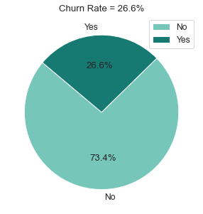

```python
# check the label
count = EDA_data['Churn Label'].value_counts()
percent = EDA_data['Churn Label'].value_counts(normalize=True).mul(100).round(1).astype(str) + '%'
print('Churn distribution:')
print('Number of No (not churn): {} | {}'.format(count[0], percent[0]))
print('Number of Yes (churn) : {} | {}'.format(count[1], percent[1]))

colors = [cp[-2], cp[-1]]
plt.pie(count, labels=['No','Yes'],
        autopct='%1.1f%%',
        colors = colors,
        startangle=140)
plt.legend(labels=['No','Yes'])
plt.title('Churn Rate = '+percent[1])
plt.show()
```

```python
# seperate categorical and numerical columns
categorical = EDA_data.select_dtypes(include='object').columns.tolist()
categorical.remove('Churn Reason')
categorical.remove('Churn Label')
numerical = EDA_data.select_dtypes(exclude='object').columns.tolist()
numerical.remove('Churn Value')
print(categorical)
print(numerical)
```

```
['City', 'Gender', 'Senior Citizen', 'Partner', 'Dependents', 'Phone Service', 'Multiple Lines', 'Internet Service', 'Online Security', 'Online Backup', 'Device Protection', 'Tech Support', 'Streaming TV', 'Streaming Movies', 'Contract', 'Paperless Billing', 'Payment Method']
['Zip Code', 'Tenure Months', 'Monthly Charges', 'Total Charges', 'Churn Score', 'CLTV']
```

### Plot Distributions

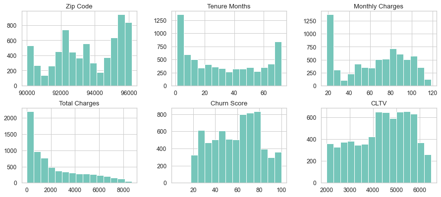

```python
# Numerical variables histograms
sns.set(style='whitegrid', palette=cp[4:], font_scale=1.1, rc={'figure.figsize': [8, 5]})
EDA_data[numerical].hist(bins=15, figsize=(15, 10), layout=(3, 3));
```

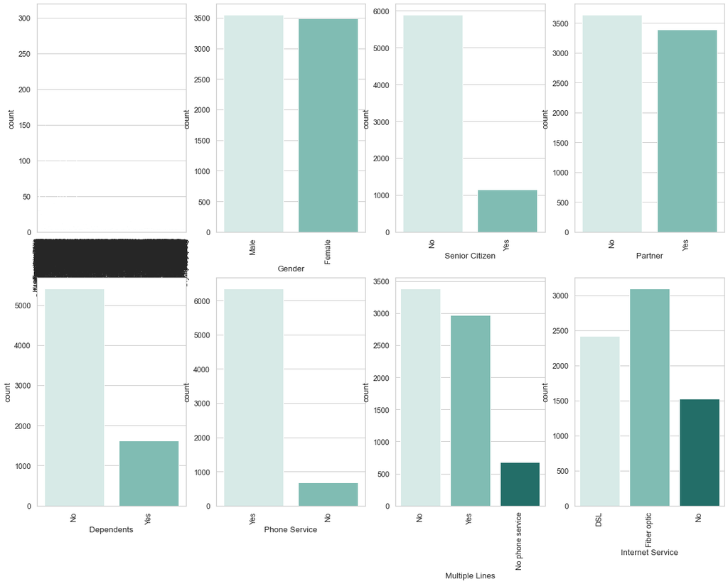

```python
# Categorical variables count plots
fig, ax = plt.subplots(2, 4, figsize=(20, 15))
for variable, subplot in zip(categorical, ax.flatten()):
    sns.countplot(EDA_data[variable], ax=subplot, palette=cp[3:])
    for label in subplot.get_xticklabels():
        label.set_rotation(90)
```

We found that 'City' has a extremly high cardinality (too many unique values). Let's take a closer look.

```
Los Angeles      304
San Diego        150
San Jose         112
Sacramento       108
San Francisco    104
                ...
Point Arena        4
Independence       3
Cupertino          3
Ben Lomond         3
Redcrest           3
Name: City, Length: 1129, dtype: int64
City
4       798
5       169
8        46
10       33
12       19
15       12
16       12
20        8
25        5
3         4
28        4
24        2
30        2
32        2
40        2
27        1
11        1
44        1
52        1
60        1
64        1
104       1
108       1
112       1
150       1
304       1
dtype: int64
```

```
array([[<AxesSubplot:title={'center':'City'}>]], dtype=object)
```

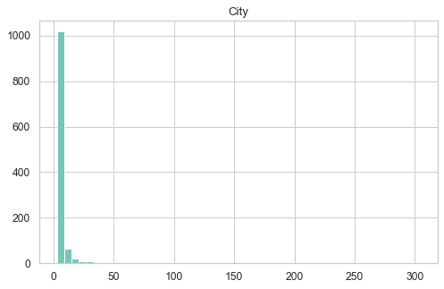

```python
counts = pd.DataFrame(EDA_data['City'].value_counts())
print(EDA_data['City'].value_counts())
print(counts.value_counts())
counts.hist(bins=50)
```

As we see, there are only a few of them have high frequencies. Most of the cities have a counts that is lower than 100. We can group the city with counts < 100 as 'other'.

```python
# group the city with counts < 100 as 'other'
other = counts.sort_values(by='City').index.tolist()[:-5]
EDA_data['City with other'] = EDA_data['City'].replace(other, 'other')
EDA_data.groupby('City with other').agg({'Churn Value':['sum', 'mean']})
```

| City with other | Churn Value sum | Churn Value mean |
| --- | --- | --- |
| Los Angeles | 90 | 0.296053 |
| Sacramento | 26 | 0.240741 |
| San Diego | 50 | 0.333333 |
| San Francisco | 31 | 0.298077 |
| San Jose | 29 | 0.258929 |
| other | 1643 | 0.262712 |

If we group cities with frequencies < 100 as 'other', 'other' will have significantly high number of churns. This will create more noise for our model. The best decision so far is to drop 'City' because its caridinality is to high to be dealt with. If we keep it as it is, 'City' will cause more problems like the curse of high dimensionality.

### Categorical Variables and Churn

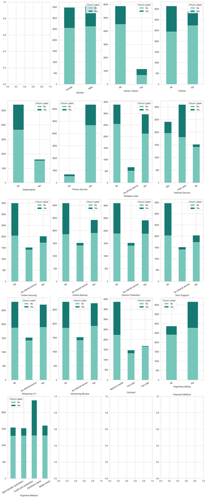

```python
# Categorical variables
fig, ax = plt.subplots(5, 4, figsize=(20, 50))
for var, subplot in zip(categorical, ax.flatten()):
    if var == 'City':
        pass
    else:
        pd.crosstab(EDA_data[var],EDA_data['Churn Label']).plot.bar(stacked=True, ax=subplot)
        plt.title(var)
        for label in subplot.get_xticklabels():
            label.set_rotation(30)
```

```python
for var in categorical:
    if var != 'City':
        percent = EDA_data.groupby(var)['Churn Value'].sum()/EDA_data[var].value_counts()
        percent100 = percent.mul(100).round(1)
        print(var)
        print(percent100)
        print('')
```

```
Gender
Female    27.0
Male      26.2
dtype: float64

Senior Citizen
Senior Citizen
No     23.7
Yes    41.7
dtype: float64

Partner
Partner
No     33.0
Yes    19.7
dtype: float64

Dependents
Dependents
No     32.6
Yes     6.5
dtype: float64

Phone Service
No     25.0
Yes    26.7
dtype: float64

Multiple Lines
No                  25.1
No phone service    25.0
Yes                 28.6
dtype: float64

Internet Service
DSL            19.0
Fiber optic    41.9
No              7.4
dtype: float64

```

[output cut: 38 more lines]

```
One year          11.3
Two year           2.8
dtype: float64

Paperless Billing
No     16.4
Yes    33.6
dtype: float64

Payment Method
Bank transfer (automatic)    16.7
Credit card (automatic)      15.3
Electronic check             45.3
Mailed check                 19.2
dtype: float64
```

We can conclude that 'Gender', 'Phone Service' and 'Mutiple Lines' do not make differences in customer churn. Other categorical variables all have some impact on churn behaviour. For example, customers using 'Electronic check' has much higher chance to churn comparing to other payment methods.

### Numerical Variables and Churn

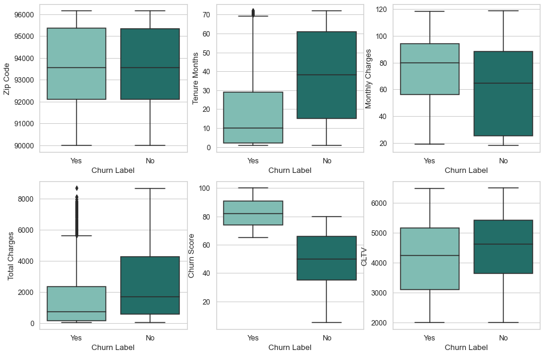

```python
# Numerical variables box plot
fig, ax = plt.subplots(2, 3, figsize=(15, 10))
for var, subplot in zip(numerical, ax.flatten()):
    sns.boxplot(x='Churn Label', y=var, data=EDA_data, ax=subplot)
```

```python
# Churn reasons
EDA_data['Churn Reason'].value_counts()
```

```
Attitude of support person                   192
Competitor offered higher download speeds    189
Competitor offered more data                 162
Don't know                                   154
Competitor made better offer                 140
Attitude of service provider                 135
Competitor had better devices                130
Network reliability                          103
Product dissatisfaction                      102
Price too high                                98
Service dissatisfaction                       89
Lack of self-service on Website               88
Extra data charges                            57
Moved                                         53
Limited range of services                     44
Long distance charges                         44
Lack of affordable download/upload speed      44
Poor expertise of phone support               20
Poor expertise of online support              19
Deceased                                       6
Name: Churn Reason, dtype: int64
```

# Prep Data for Modelling (Feature Engineering)

- Drop features that are not helpful for churn classification
- Encode categorical features
- Normalize numerical features

### Drop features that are not helpful for churn classification

```python
# include the features needed to be dropped after EDA
feature_drop = to_drop_after_EDA
# drop the features that are identified in the EDA as being not helpful
feature_drop.extend(['Gender', 'Phone Service', 'Multiple Lines', 'Zip Code', 'CLTV', 'City', 'City with other'])

data = EDA_data.drop(columns=feature_drop)
data.head()
```

|  | Senior Citizen | Partner | Dependents | Tenure Months | Internet Service | Online Security | Online Backup | Device Protection | Tech Support | Streaming TV | Streaming Movies | Contract | Paperless Billing | Payment Method | Monthly Charges | Total Charges | Churn Value | Churn Score |
| --- | --- | --- | --- | --- | --- | --- | --- | --- | --- | --- | --- | --- | --- | --- | --- | --- | --- | --- |
| 0 | No | No | No | 2 | DSL | Yes | Yes | No | No | No | No | Month-to-month | Yes | Mailed check | 53.85 | 108.15 | 1 | 86 |
| 1 | No | No | Yes | 2 | Fiber optic | No | No | No | No | No | No | Month-to-month | Yes | Electronic check | 70.70 | 151.65 | 1 | 67 |
| 2 | No | No | Yes | 8 | Fiber optic | No | No | Yes | No | Yes | Yes | Month-to-month | Yes | Electronic check | 99.65 | 820.50 | 1 | 86 |
| 3 | No | Yes | Yes | 28 | Fiber optic | No | No | Yes | Yes | Yes | Yes | Month-to-month | Yes | Electronic check | 104.80 | 3046.05 | 1 | 84 |
| 4 | No | No | Yes | 49 | Fiber optic | No | Yes | Yes | No | Yes | Yes | Month-to-month | Yes | Bank transfer (automatic) | 103.70 | 5036.30 | 1 | 89 |

### One Hot Encode categorical features

```python
ohe_columns = data.select_dtypes(include='object').columns.tolist()
print(ohe_columns)
```

```
['Senior Citizen', 'Partner', 'Dependents', 'Internet Service', 'Online Security', 'Online Backup', 'Device Protection', 'Tech Support', 'Streaming TV', 'Streaming Movies', 'Contract', 'Paperless Billing', 'Payment Method']
```

```python
data = pd.get_dummies(data, columns=ohe_columns, drop_first=True)
print(data.shape)
data.head()
```

```
(7032, 28)
```

|  | Tenure Months | Monthly Charges | Total Charges | Churn Value | Churn Score | Senior Citizen_Yes | Partner_Yes | Dependents_Yes | Internet Service_Fiber optic | Internet Service_No | Online Security_No internet service | Online Security_Yes | Online Backup_No internet service | Online Backup_Yes | Device Protection_No internet service | Device Protection_Yes | Tech Support_No internet service | Tech Support_Yes | Streaming TV_No internet service | Streaming TV_Yes | Streaming Movies_No internet service | Streaming Movies_Yes | Contract_One year | Contract_Two year | Paperless Billing_Yes | Payment Method_Credit card (automatic) | Payment Method_Electronic check | Payment Method_Mailed check |
| --- | --- | --- | --- | --- | --- | --- | --- | --- | --- | --- | --- | --- | --- | --- | --- | --- | --- | --- | --- | --- | --- | --- | --- | --- | --- | --- | --- | --- |
| 0 | 2 | 53.85 | 108.15 | 1 | 86 | 0 | 0 | 0 | 0 | 0 | 0 | 1 | 0 | 1 | 0 | 0 | 0 | 0 | 0 | 0 | 0 | 0 | 0 | 0 | 1 | 0 | 0 | 1 |
| 1 | 2 | 70.70 | 151.65 | 1 | 67 | 0 | 0 | 1 | 1 | 0 | 0 | 0 | 0 | 0 | 0 | 0 | 0 | 0 | 0 | 0 | 0 | 0 | 0 | 0 | 1 | 0 | 1 | 0 |
| 2 | 8 | 99.65 | 820.50 | 1 | 86 | 0 | 0 | 1 | 1 | 0 | 0 | 0 | 0 | 0 | 0 | 1 | 0 | 0 | 0 | 1 | 0 | 1 | 0 | 0 | 1 | 0 | 1 | 0 |
| 3 | 28 | 104.80 | 3046.05 | 1 | 84 | 0 | 1 | 1 | 1 | 0 | 0 | 0 | 0 | 0 | 0 | 1 | 0 | 1 | 0 | 1 | 0 | 1 | 0 | 0 | 1 | 0 | 1 | 0 |
| 4 | 49 | 103.70 | 5036.30 | 1 | 89 | 0 | 0 | 1 | 1 | 0 | 0 | 0 | 0 | 1 | 0 | 1 | 0 | 0 | 0 | 1 | 0 | 1 | 0 | 0 | 1 | 0 | 0 | 0 |

There are many rows called "...No internet service". There might be duplicated columns with "Internet Service_No".

```python
No_internet_service_columns = [column for column in data.columns.tolist() if 'No internet service' in column]
No_internet_service_columns.append('Internet Service_No')
print(No_internet_service_columns)
```

```
['Online Security_No internet service', 'Online Backup_No internet service', 'Device Protection_No internet service', 'Tech Support_No internet service', 'Streaming TV_No internet service', 'Streaming Movies_No internet service', 'Internet Service_No']
```

```python
print('Total rows:', len(data))
print('Duplicated rows:', data[No_internet_service_columns].duplicated().count())
```

```
Total rows: 7032
Duplicated rows: 7032
```

We confirmed that they duplicated. Let's only keep "Internet Service_No".

```python
No_internet_service_columns.pop(-1)
data.drop(columns=No_internet_service_columns, inplace=True)
print(data.shape)
data.head()
```

```
(7032, 22)
```

|  | Tenure Months | Monthly Charges | Total Charges | Churn Value | Churn Score | Senior Citizen_Yes | Partner_Yes | Dependents_Yes | Internet Service_Fiber optic | Internet Service_No | Online Security_Yes | Online Backup_Yes | Device Protection_Yes | Tech Support_Yes | Streaming TV_Yes | Streaming Movies_Yes | Contract_One year | Contract_Two year | Paperless Billing_Yes | Payment Method_Credit card (automatic) | Payment Method_Electronic check | Payment Method_Mailed check |
| --- | --- | --- | --- | --- | --- | --- | --- | --- | --- | --- | --- | --- | --- | --- | --- | --- | --- | --- | --- | --- | --- | --- |
| 0 | 2 | 53.85 | 108.15 | 1 | 86 | 0 | 0 | 0 | 0 | 0 | 1 | 1 | 0 | 0 | 0 | 0 | 0 | 0 | 1 | 0 | 0 | 1 |
| 1 | 2 | 70.70 | 151.65 | 1 | 67 | 0 | 0 | 1 | 1 | 0 | 0 | 0 | 0 | 0 | 0 | 0 | 0 | 0 | 1 | 0 | 1 | 0 |
| 2 | 8 | 99.65 | 820.50 | 1 | 86 | 0 | 0 | 1 | 1 | 0 | 0 | 0 | 1 | 0 | 1 | 1 | 0 | 0 | 1 | 0 | 1 | 0 |
| 3 | 28 | 104.80 | 3046.05 | 1 | 84 | 0 | 1 | 1 | 1 | 0 | 0 | 0 | 1 | 1 | 1 | 1 | 0 | 0 | 1 | 0 | 1 | 0 |
| 4 | 49 | 103.70 | 5036.30 | 1 | 89 | 0 | 0 | 1 | 1 | 0 | 0 | 1 | 1 | 0 | 1 | 1 | 0 | 0 | 1 | 0 | 0 | 0 |

### Normalize numerical features

```python
mms = MinMaxScaler()

norm_columns = ['Tenure Months', 'Monthly Charges', 'Total Charges']
rescaled = mms.fit_transform(data[norm_columns])
data[norm_columns] = rescaled
data.head()
```

|  | Tenure Months | Monthly Charges | Total Charges | Churn Value | Churn Score | Senior Citizen_Yes | Partner_Yes | Dependents_Yes | Internet Service_Fiber optic | Internet Service_No | Online Security_Yes | Online Backup_Yes | Device Protection_Yes | Tech Support_Yes | Streaming TV_Yes | Streaming Movies_Yes | Contract_One year | Contract_Two year | Paperless Billing_Yes | Payment Method_Credit card (automatic) | Payment Method_Electronic check | Payment Method_Mailed check |
| --- | --- | --- | --- | --- | --- | --- | --- | --- | --- | --- | --- | --- | --- | --- | --- | --- | --- | --- | --- | --- | --- | --- |
| 0 | 0.014085 | 0.354229 | 0.010310 | 1 | 86 | 0 | 0 | 0 | 0 | 0 | 1 | 1 | 0 | 0 | 0 | 0 | 0 | 0 | 1 | 0 | 0 | 1 |
| 1 | 0.014085 | 0.521891 | 0.015330 | 1 | 67 | 0 | 0 | 1 | 1 | 0 | 0 | 0 | 0 | 0 | 0 | 0 | 0 | 0 | 1 | 0 | 1 | 0 |
| 2 | 0.098592 | 0.809950 | 0.092511 | 1 | 86 | 0 | 0 | 1 | 1 | 0 | 0 | 0 | 1 | 0 | 1 | 1 | 0 | 0 | 1 | 0 | 1 | 0 |
| 3 | 0.380282 | 0.861194 | 0.349325 | 1 | 84 | 0 | 1 | 1 | 1 | 0 | 0 | 0 | 1 | 1 | 1 | 1 | 0 | 0 | 1 | 0 | 1 | 0 |
| 4 | 0.676056 | 0.850249 | 0.578987 | 1 | 89 | 0 | 0 | 1 | 1 | 0 | 0 | 1 | 1 | 0 | 1 | 1 | 0 | 0 | 1 | 0 | 0 | 0 |

```python
# Features are ready for training model
  # NO null values
  # NO non-numeric data
  # Normalization applied
data.info()
```

```
<class 'pandas.core.frame.DataFrame'>
Int64Index: 7032 entries, 0 to 7042
Data columns (total 22 columns):
 #   Column                                  Non-Null Count  Dtype
---  ------                                  --------------  -----
 0   Tenure Months                           7032 non-null   float64
 1   Monthly Charges                         7032 non-null   float64
 2   Total Charges                           7032 non-null   float64
 3   Churn Value                             7032 non-null   int64
 4   Churn Score                             7032 non-null   int64
 5   Senior Citizen_Yes                      7032 non-null   uint8
 6   Partner_Yes                             7032 non-null   uint8
 7   Dependents_Yes                          7032 non-null   uint8
 8   Internet Service_Fiber optic            7032 non-null   uint8
 9   Internet Service_No                     7032 non-null   uint8
 10  Online Security_Yes                     7032 non-null   uint8
 11  Online Backup_Yes                       7032 non-null   uint8
 12  Device Protection_Yes                   7032 non-null   uint8
 13  Tech Support_Yes                        7032 non-null   uint8
 14  Streaming TV_Yes                        7032 non-null   uint8
 15  Streaming Movies_Yes                    7032 non-null   uint8
 16  Contract_One year                       7032 non-null   uint8
 17  Contract_Two year                       7032 non-null   uint8
 18  Paperless Billing_Yes                   7032 non-null   uint8
 19  Payment Method_Credit card (automatic)  7032 non-null   uint8
 20  Payment Method_Electronic check         7032 non-null   uint8
 21  Payment Method_Mailed check             7032 non-null   uint8
dtypes: float64(3), int64(2), uint8(17)
memory usage: 704.4 KB
```

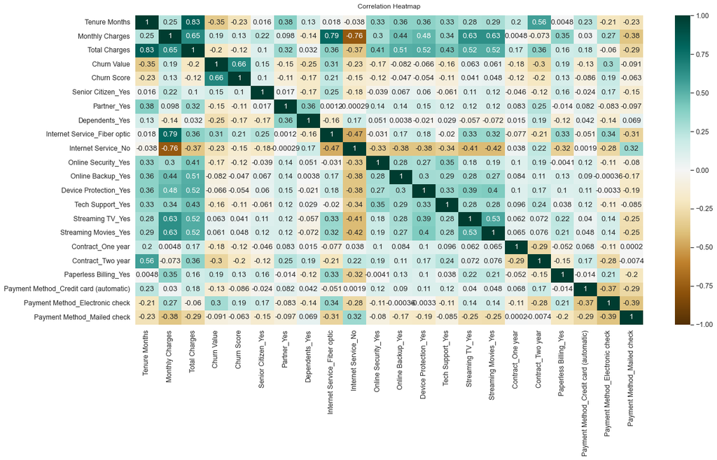

```python
# take a look at the feature correlations
plt.figure(figsize=(20, 10))
heatmap = sns.heatmap(data.corr(), vmin=-1, vmax=1, annot=True, cmap='BrBG')
heatmap.set_title('Correlation Heatmap', fontdict={'fontsize':12}, pad=12);
```

We can see that there are two pairs of features are higly correlated with each other:

- 'Tenure Months' and 'Total Charges'
- 'Monthly Charges' and 'Internet Service_Fiber optic'

This introduced the multi-colinearity problem. We will use PCA to solve this problem.

### Apply PCA

```python
# use standard scaler to scale data
from sklearn.preprocessing import StandardScaler, RobustScaler, MinMaxScaler
from sklearn.decomposition import PCA
standard_scalar = StandardScaler()

model = PCA(n_components=1)
data_pca_1 = standard_scalar.fit_transform(data[['Tenure Months', 'Total Charges']])
data_pca_1_final = model.fit_transform(data_pca_1)

data_pca_2 = standard_scalar.fit_transform(data[['Monthly Charges', 'Internet Service_Fiber optic']])
data_pca_2_final = model.fit_transform(data_pca_2)

# move PCA components into dataframe
pca_data = data.drop(columns=['Tenure Months', 'Total Charges', 'Monthly Charges', 'Internet Service_Fiber optic'])
pca_data['pca1'] = data_pca_1_final
pca_data['pca2'] = data_pca_2_final
pca_data
```

|  | Churn Value | Churn Score | Senior Citizen_Yes | Partner_Yes | Dependents_Yes | Internet Service_No | Online Security_Yes | Online Backup_Yes | Device Protection_Yes | Tech Support_Yes | Streaming TV_Yes | Streaming Movies_Yes | Contract_One year | Contract_Two year | Paperless Billing_Yes | Payment Method_Credit card (automatic) | Payment Method_Electronic check | Payment Method_Mailed check | pca1 | pca2 |
| --- | --- | --- | --- | --- | --- | --- | --- | --- | --- | --- | --- | --- | --- | --- | --- | --- | --- | --- | --- | --- |
| 0 | 1 | 86 | 0 | 0 | 0 | 0 | 1 | 1 | 0 | 0 | 0 | 0 | 0 | 0 | 1 | 0 | 0 | 1 | -1.555036 | -0.884463 |
| 1 | 1 | 67 | 0 | 0 | 1 | 0 | 0 | 0 | 0 | 0 | 0 | 0 | 0 | 0 | 1 | 0 | 1 | 0 | -1.541466 | 0.936001 |
| 2 | 1 | 86 | 0 | 0 | 1 | 0 | 0 | 0 | 1 | 0 | 1 | 1 | 0 | 0 | 1 | 0 | 1 | 0 | -1.159945 | 1.616458 |
| 3 | 1 | 84 | 0 | 1 | 1 | 0 | 0 | 0 | 1 | 1 | 1 | 1 | 0 | 0 | 1 | 0 | 1 | 0 | 0.110559 | 1.737506 |
| 4 | 1 | 89 | 0 | 0 | 1 | 0 | 0 | 1 | 1 | 0 | 1 | 1 | 0 | 0 | 1 | 0 | 0 | 0 | 1.336468 | 1.711651 |
| ... | ... | ... | ... | ... | ... | ... | ... | ... | ... | ... | ... | ... | ... | ... | ... | ... | ... | ... | ... | ... |
| 7038 | 0 | 45 | 0 | 0 | 0 | 1 | 0 | 0 | 0 | 0 | 0 | 0 | 0 | 1 | 1 | 0 | 0 | 0 | 0.870753 | -1.653062 |
| 7039 | 0 | 59 | 0 | 1 | 1 | 0 | 1 | 0 | 1 | 1 | 1 | 1 | 1 | 0 | 1 | 0 | 0 | 1 | -0.333978 | -0.156998 |
| 7040 | 0 | 71 | 0 | 1 | 1 | 0 | 0 | 1 | 1 | 0 | 1 | 1 | 1 | 0 | 1 | 1 | 0 | 0 | 2.724927 | 1.699899 |
| 7041 | 0 | 59 | 0 | 1 | 1 | 0 | 1 | 0 | 0 | 0 | 0 | 0 | 0 | 0 | 1 | 0 | 1 | 0 | -1.221401 | -1.454448 |
| 7042 | 0 | 38 | 0 | 0 | 0 | 0 | 1 | 0 | 1 | 1 | 1 | 1 | 0 | 1 | 1 | 0 | 0 | 0 | 2.390342 | 1.757485 |

7032 rows × 20 columns

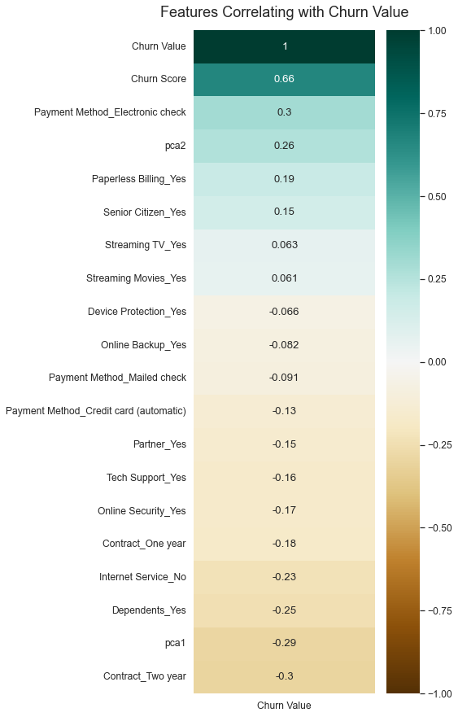

```python
plt.figure(figsize=(5, 15))
heatmap = sns.heatmap(pca_data.corr()[['Churn Value']].sort_values(by='Churn Value', ascending=False), vmin=-1, vmax=1, annot=True, cmap='BrBG')
heatmap.set_title('Features Correlating with Churn Value', fontdict={'fontsize':18}, pad=16);
```

```python
# create copies of the data for supervised learning
# use churn value as the target variable
X = pca_data.drop(columns=['Churn Value'])
Y = pca_data['Churn Value']
```

```python
X.head()
```

|  | Churn Score | Senior Citizen_Yes | Partner_Yes | Dependents_Yes | Internet Service_No | Online Security_Yes | Online Backup_Yes | Device Protection_Yes | Tech Support_Yes | Streaming TV_Yes | Streaming Movies_Yes | Contract_One year | Contract_Two year | Paperless Billing_Yes | Payment Method_Credit card (automatic) | Payment Method_Electronic check | Payment Method_Mailed check | pca1 | pca2 |
| --- | --- | --- | --- | --- | --- | --- | --- | --- | --- | --- | --- | --- | --- | --- | --- | --- | --- | --- | --- |
| 0 | 86 | 0 | 0 | 0 | 0 | 1 | 1 | 0 | 0 | 0 | 0 | 0 | 0 | 1 | 0 | 0 | 1 | -1.555036 | -0.884463 |
| 1 | 67 | 0 | 0 | 1 | 0 | 0 | 0 | 0 | 0 | 0 | 0 | 0 | 0 | 1 | 0 | 1 | 0 | -1.541466 | 0.936001 |
| 2 | 86 | 0 | 0 | 1 | 0 | 0 | 0 | 1 | 0 | 1 | 1 | 0 | 0 | 1 | 0 | 1 | 0 | -1.159945 | 1.616458 |
| 3 | 84 | 0 | 1 | 1 | 0 | 0 | 0 | 1 | 1 | 1 | 1 | 0 | 0 | 1 | 0 | 1 | 0 | 0.110559 | 1.737506 |
| 4 | 89 | 0 | 0 | 1 | 0 | 0 | 1 | 1 | 0 | 1 | 1 | 0 | 0 | 1 | 0 | 0 | 0 | 1.336468 | 1.711651 |

```python
Y.head()
```

```
0    1
1    1
2    1
3    1
4    1
Name: Churn Value, dtype: int64
```

# Modelling

```python
# split data into train and test sets (80/20 split)
X_train, X_test, y_train, y_test = train_test_split(X, Y, train_size = 0.8, random_state=6, stratify=Y)
```

### Initial Vanilla Training

```python
# Stochastic Gradient Descent (SGD):
sgd = SGDClassifier()
# Train the model on the training data
sgd.fit(X_train, y_train)
# Test performance of SGD on validation set
acc_sgd = round(sgd.score(X_test, y_test) * 100, 2)
# Repeat with other ML models

# XGBoost
xgb = XGBClassifier()
xgb.fit(X_train, y_train)
acc_xgb_boost = round(xgb.score(X_test, y_test) * 100, 2)

# Random Forest
rf = RandomForestClassifier()
rf.fit(X_train, y_train)
acc_random_forest = round(rf.score(X_test, y_test) * 100, 2)

# Logistic Regression
logreg = LogisticRegression()
logreg.fit(X_train, y_train)
acc_log = round(logreg.score(X_test, y_test) * 100, 2)

# K Nearest Neighbor
knn = KNeighborsClassifier(n_neighbors = 3)
knn.fit(X_train, y_train)
acc_knn = round(knn.score(X_test, y_test) * 100, 2)

# Gaussian Naive Bayes
gaussian = GaussianNB()
gaussian.fit(X_train, y_train)
acc_gaussian = round(gaussian.score(X_test, y_test) * 100, 2)

# Percepton
perceptron = Perceptron(max_iter=5)
perceptron.fit(X_train, y_train)
acc_perceptron = round(perceptron.score(X_test, y_test) * 100, 2)

# Linear Suppport Vector Machine
linear_svc = LinearSVC()
linear_svc.fit(X_train, y_train)
acc_linear_svc = round(linear_svc.score(X_test, y_test) * 100, 2)

# Decision Tree Classifier
decision_tree = DecisionTreeClassifier()
decision_tree.fit(X_train, y_train)
acc_decision_tree = round(decision_tree.score(X_test, y_test) * 100, 2)
```

```
[16:22:10] WARNING: ../src/learner.cc:1115: Starting in XGBoost 1.3.0, the default evaluation metric used with the objective 'binary:logistic' was changed from 'error' to 'logloss'. Explicitly set eval_metric if you'd like to restore the old behavior.
```

```python
# Compare accuracy of models on validation set to find the best model
# Create dataframe of models with accuracy scores on validation set
model_results = pd.DataFrame({
    'Model': ['Support Vector Machines', 'KNN', 'Logistic Regression',
              'Random Forest', 'Naive Bayes', 'Perceptron',
              'Stochastic Gradient Decent',
              'Decision Tree', 'XGBoost'],
    'Score': [acc_linear_svc, acc_knn, acc_log,
              acc_random_forest, acc_gaussian, acc_perceptron,
              acc_sgd, acc_decision_tree, acc_xgb_boost]})
result_df = model_results.sort_values(by='Score', ascending=False)
results_df = result_df.set_index('Score')
print('\n','Model Accuracy Scores on Test Set')
print(result_df)
print('\n', '-'*25, '\n')
```

```
 Model Accuracy Scores on Test Set
                        Model  Score
3               Random Forest  93.32
8                     XGBoost  93.03
2         Logistic Regression  92.54
7               Decision Tree  91.83
6  Stochastic Gradient Decent  91.68
1                         KNN  91.54
0     Support Vector Machines  90.90
4                 Naive Bayes  87.14
5                  Perceptron  73.42

 -------------------------
```

Random Forest performs best on the validation model, move forward with these models

### Model Selection

```python
# Aplly 10-Fold Cross-Validation
def cross_validation(model, X, y, cv=5):
    scoring = ['accuracy', 'precision', 'recall', 'f1']
    results = cross_validate(estimator=model,
                               X=X,
                               y=y,
                               cv=cv,
                               scoring=scoring,
                               return_train_score=True)

    return {
            "Mean Validation Accuracy": results['test_accuracy'].mean()*100,
            "Mean Validation Precision": results['test_precision'].mean(),
            "Mean Validation Recall": results['test_recall'].mean(),
            "Mean Validation F1 Score": results['test_f1'].mean(),
            "Mean Training Accuracy": results['train_accuracy'].mean()*100,
            "Mean Training Precision": results['train_precision'].mean(),
            "Mean Training Recall": results['train_recall'].mean(),
            "Mean Training F1 Score": results['train_f1'].mean(),
          }
```

```python
models = {'Stochastic Gradient Decent': SGDClassifier(),
          'XGBoost': XGBClassifier(use_label_encoder=False, eval_metric='logloss'),
          'Random Forest': RandomForestClassifier(),
          'Logistic Regression': LogisticRegression(),
          'KNN': KNeighborsClassifier(n_neighbors = 3),
          'Naive Bayes': GaussianNB(),
          'Perceptron': Perceptron(max_iter=5),
          'Support Vector Machines': LinearSVC(),
          'Decision Tree': DecisionTreeClassifier()}

results = {}
for model_name, model in models.items():
    results[model_name] = cross_validation(model, X_train, y_train, cv=10)

df_results = pd.DataFrame.from_dict(results, orient='index').sort_values(by='Mean Validation Accuracy', ascending=False)
df_results
```

|  | Mean Validation Accuracy | Mean Validation Precision | Mean Validation Recall | Mean Validation F1 Score | Mean Training Accuracy | Mean Training Precision | Mean Training Recall | Mean Training F1 Score |
| --- | --- | --- | --- | --- | --- | --- | --- | --- |
| Random Forest | 92.782438 | 0.880307 | 0.843472 | 0.860887 | 100.000000 | 1.000000 | 1.000000 | 1.000000 |
| XGBoost | 92.053754 | 0.859988 | 0.838121 | 0.848510 | 99.770868 | 0.994372 | 0.997027 | 0.995697 |
| Logistic Regression | 91.627434 | 0.846946 | 0.836841 | 0.841631 | 91.853826 | 0.848179 | 0.844743 | 0.846443 |
| Decision Tree | 91.093184 | 0.830309 | 0.836752 | 0.833050 | 100.000000 | 1.000000 | 1.000000 | 1.000000 |
| KNN | 90.933863 | 0.821547 | 0.842157 | 0.831409 | 95.032112 | 0.899114 | 0.915868 | 0.907407 |
| Stochastic Gradient Decent | 89.262530 | 0.869676 | 0.724510 | 0.776390 | 89.639502 | 0.876914 | 0.732803 | 0.783619 |
| Support Vector Machines | 89.031403 | 0.832558 | 0.802049 | 0.789377 | 88.873096 | 0.830424 | 0.798284 | 0.788705 |
| Naive Bayes | 86.436066 | 0.715539 | 0.816076 | 0.762137 | 86.502719 | 0.714883 | 0.818730 | 0.763282 |
| Perceptron | 70.305367 | 0.479827 | 0.571915 | 0.410194 | 70.467771 | 0.458182 | 0.576512 | 0.412575 |

Random Forest, XGBoost, Logistic Regression, Decision Tree and KNN performed well consistenly with validation accuracies > 90% and validation F1 socre > 80

```python
# Model Training
selected_models = {'XGBoost': XGBClassifier(use_label_encoder=False, eval_metric='logloss'),
                   'Random Forest': RandomForestClassifier(),
                   'Logistic Regression': LogisticRegression(),
                   'Decision Tree': DecisionTreeClassifier(),
                   'KNN': KNeighborsClassifier(n_neighbors = 3)}
trained_models = {}
for name, model in selected_models.items():
    trained_models[name] = model.fit(X_train, y_train)
```

### Model Selection and Training without 'Churn Score'

```python
# drop 'Churn Score' from X
X2 = X.drop(columns=['Churn Score'])
# split data into train and test sets (80/20 split)
X2_train, X2_test, y_train, y_test = train_test_split(X2, Y, train_size = 0.8, random_state=6, stratify=Y)

# 10-Fold Cross validation
results2 = {}
for model_name, model in models.items():
    results2[model_name] = cross_validation(model, X2_train, y_train, cv=10)

df_results2 = pd.DataFrame.from_dict(results2, orient='index').sort_values(by='Mean Validation Accuracy', ascending=False)
df_results2
```

|  | Mean Validation Accuracy | Mean Validation Precision | Mean Validation Recall | Mean Validation F1 Score | Mean Training Accuracy | Mean Training Precision | Mean Training Recall | Mean Training F1 Score |
| --- | --- | --- | --- | --- | --- | --- | --- | --- |
| Logistic Regression | 80.551917 | 0.659098 | 0.561897 | 0.604940 | 80.679514 | 0.660855 | 0.560907 | 0.606787 |
| Support Vector Machines | 80.391744 | 0.657576 | 0.553857 | 0.599306 | 80.594578 | 0.660684 | 0.554813 | 0.603132 |
| Random Forest | 79.342775 | 0.638676 | 0.515069 | 0.568948 | 99.727408 | 0.995535 | 0.994203 | 0.994868 |
| Stochastic Gradient Decent | 79.325139 | 0.642633 | 0.527848 | 0.565780 | 79.512077 | 0.648780 | 0.534289 | 0.572618 |
| XGBoost | 78.880489 | 0.622574 | 0.531145 | 0.572105 | 94.214340 | 0.909725 | 0.868525 | 0.888626 |
| KNN | 76.960013 | 0.571441 | 0.541808 | 0.554985 | 87.397533 | 0.786247 | 0.722186 | 0.752846 |
| Naive Bayes | 75.964552 | 0.534237 | 0.764564 | 0.628602 | 75.999998 | 0.533837 | 0.765441 | 0.628989 |
| Decision Tree | 73.653565 | 0.503921 | 0.518421 | 0.510750 | 99.729384 | 0.998355 | 0.991453 | 0.994891 |
| Perceptron | 69.990708 | 0.432821 | 0.328747 | 0.336830 | 70.611444 | 0.450991 | 0.338728 | 0.347921 |

Without 'Churn Score', model performed mush worse. It seems that 'Churn Score' represents some critical factors that were not represent by other features in this dataset. We will only select the top 2 models.

```python
# Model Training
selected2_models = {'Logistic Regression': LogisticRegression(),
                    'Support Vector Machines': LinearSVC()}

trained2_models = {}
for name, model in selected2_models.items():
    trained2_models[name] = model.fit(X2_train, y_train)
```

# Model Evaluation

[figure not shown]

[figure not shown]

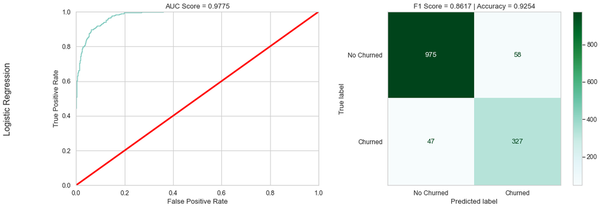

[figure not shown]

[figure not shown]

```python
for name, model in trained_models.items():
    # calculate accuracy
    acc = model.score(X_test, y_test)
    # make prediction
    y_pred = model.predict(X_test)
    # calculate f1 score
    f1 = f1_score(y_test, y_pred)
    # calculate auc roc
    y_prob = model.predict_proba(X_test)[:,1]
    rocauc_score = roc_auc_score(y_test, y_prob)
    # roc_curve
    fp_rate, tp_rate, thresholds = roc_curve(y_test, y_prob)

    # Plot fp_rate against tp_rate w/ a benchmark random classifier
    fig, (ax1, ax2) = plt.subplots(1,2, figsize=(18,6))
    ax1.plot(fp_rate, tp_rate)
    ax1.plot([0, 1], [0, 1], 'r', linewidth=3)
    ax1.axis([0, 1, 0, 1])
    ax1.set_xlabel('False Positive Rate')
    ax1.set_ylabel('True Positive Rate')
    ax1.title.set_text('AUC Score = {}'.format(rocauc_score.round(4)))

    # plot confusion matrix
    labels=['No Churned','Churned']
    plot_confusion_matrix(logreg, X_test, y_test,
                          display_labels=labels,
                          cmap=plt.cm.BuGn, ax=ax2)
    ax2.title.set_text('F1 Score = {} | Accuracy = {}'.format(f1.round(4), acc.round(4)))
    plt.grid(b=None)
    fig.supylabel(name)
    plt.show()
```

### Model evaluation without 'Churn Score'

[figure not shown]

[figure not shown]

```python
# pca model evaluation
for name, model in trained2_models.items():
    # calculate accuracy
    acc = model.score(X2_test, y_test)
    # make prediction
    y_pred = model.predict(X2_test)
    # calculate f1 score
    f1 = f1_score(y_test, y_pred)
    # calculate auc roc
    if name == 'Support Vector Machines':
        y_prob = model._predict_proba_lr(X2_test)[:,1]
    else:
        y_prob = model.predict_proba(X2_test)[:,1]
    rocauc_score = roc_auc_score(y_test, y_prob)
    # roc_curve
    fp_rate, tp_rate, thresholds = roc_curve(y_test, y_prob)

    # Plot fp_rate against tp_rate w/ a benchmark random classifier
    fig, (ax1, ax2) = plt.subplots(1,2, figsize=(18,6))
    ax1.plot(fp_rate, tp_rate)
    ax1.plot([0, 1], [0, 1], 'r', linewidth=3)
    ax1.axis([0, 1, 0, 1])
    ax1.set_xlabel('False Positive Rate')
    ax1.set_ylabel('True Positive Rate')
    ax1.title.set_text('AUC Score = {}'.format(rocauc_score.round(4)))

    # plot confusion matrix
    labels=['No Churned','Churned']
    plot_confusion_matrix(logreg, X_test, y_test,
                          display_labels=labels,
                          cmap=plt.cm.BuGn, ax=ax2)
    ax2.title.set_text('F1 Score = {} | Accuracy = {}'.format(f1.round(4), acc.round(4)))
    plt.grid(b=None)
    fig.supylabel(name)
    plt.show()
```

and the top 2 models without using 'Churn Score':

- Logistic Regression: AUC Score = 0.8528, F1 Score = 0.5985, Accuracy = 0.8074
- Support Vector Machine: AUC Score = 0.8518, F1 Score = 0.6012, Accuracy = 0.8095